# Hierarchical Clustering

# Excercises Part 1

```r
library(fivethirtyeight)
library(dplyr)
data("hate_crimes")
?hate_crimes
```

Removing crime rates so that we can discover structure among the fifty states.

```r
state_data <- hate_crimes %>%
    dplyr::select(-c(hate_crimes_per_100k_splc, avg_hatecrimes_per_100k_fbi))
```

## 1)

The types of variables remaining are all quantitative. Thus we we are trying to identify structure amongst states with similar values.

## 2)

NOTE: Heat map - Dark pink is higher than average, blue is lower than average, white is average.

```r
# Turn state variable into row names
state_sub <- state_data %>%
    dplyr::select(-state)
rownames(state_sub) <- state_data$state
```

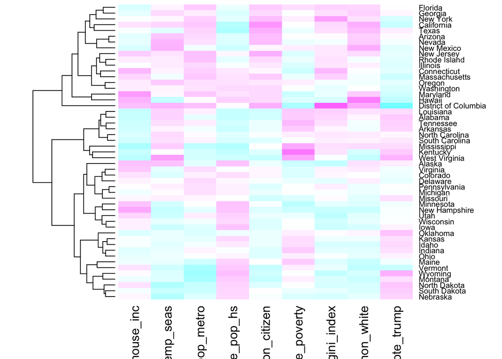

```r
# Heatmap of scaled data
heatmap(data.matrix(scale(state_sub)),
        Colv = NA, scale = "column", col = cm.colors(256))
```

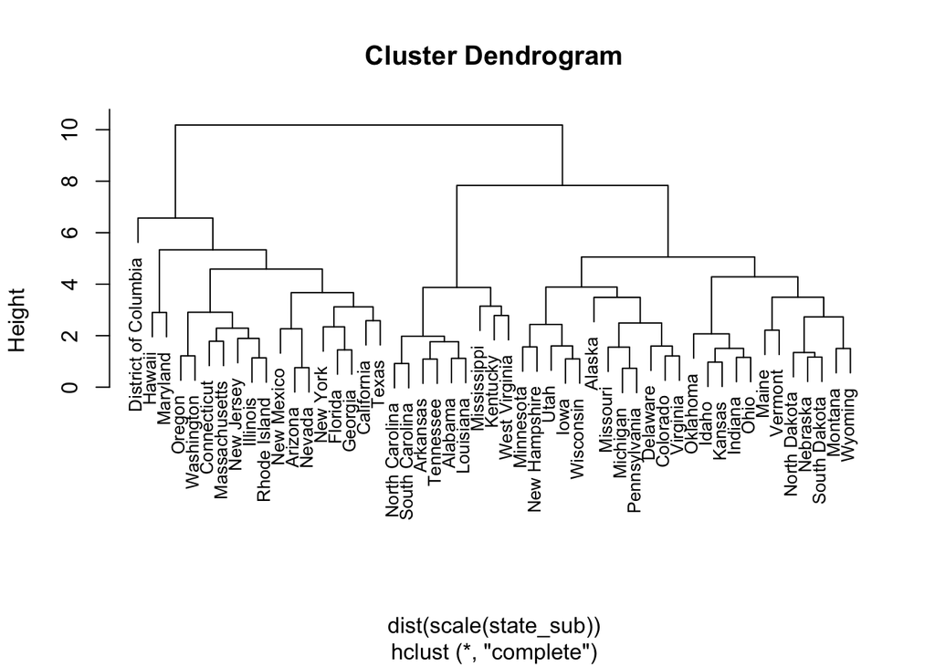

```r
# Dendrogram of scaled data
state_cluster <- hclust(dist(scale(state_sub)))
plot(state_cluster, cex = 0.8)
```

I would guess that we are scaling the data so that the data operates on an easier to compute scale for the algorithm.

## 3)

### 3a)

I would say that there appear to be four natural clusters among the states. The big one on the left with District of columbia, the cluster with the South. The cluster with Alaska. The cluster with the Dakotas.

### 3b)

New Hampshire, Utah, Iowa, Wisconsin, Alaska, Missouri, Michigan, Pennsylvania, Delaware, Colorade, and Virginia.

### 3c)

Minnesota is more similar to Alaska than West Virginia.

## 4)

### 4a)

```r
# Sort states into 3 clusters
cluster_3 <- as.factor(cutree(state_cluster, 3))
cluster_3
```

```
##              Alabama               Alaska              Arizona
##                    1                    2                    3
##             Arkansas           California             Colorado
##                    1                    3                    2
##          Connecticut             Delaware District of Columbia
##                    3                    2                    3
##              Florida              Georgia               Hawaii
##                    3                    3                    3
##                Idaho             Illinois              Indiana
##                    2                    3                    2
##                 Iowa               Kansas             Kentucky
##                    2                    2                    1
##            Louisiana                Maine             Maryland
##                    1                    2                    3
##        Massachusetts             Michigan            Minnesota
##                    3                    2                    2
##          Mississippi             Missouri              Montana
##                    1                    2                    2
##             Nebraska               Nevada        New Hampshire
##                    2                    3                    2
##           New Jersey           New Mexico             New York
##                    3                    3                    3
##       North Carolina         North Dakota                 Ohio
##                    1                    2                    2
##             Oklahoma               Oregon         Pennsylvania
##                    2                    3                    2
##         Rhode Island       South Carolina         South Dakota
##                    3                    1                    2
##            Tennessee                Texas                 Utah
##                    1                    3                    2
##              Vermont             Virginia           Washington
##                    2                    2                    3
##        West Virginia            Wisconsin              Wyoming
##                    1                    2                    2
## Levels: 1 2 3
```

```r
# Sort states into 6 clusters
cluster_6 <- as.factor(cutree(state_cluster, 6))
cluster_6
```

```
##              Alabama               Alaska              Arizona
##                    1                    2                    3
##             Arkansas           California             Colorado
##                    1                    3                    2
##          Connecticut             Delaware District of Columbia
##                    3                    2                    4
##              Florida              Georgia               Hawaii
##                    3                    3                    5
##                Idaho             Illinois              Indiana
##                    6                    3                    6
##                 Iowa               Kansas             Kentucky
##                    2                    6                    1
##            Louisiana                Maine             Maryland
##                    1                    6                    5
##        Massachusetts             Michigan            Minnesota
##                    3                    2                    2
##          Mississippi             Missouri              Montana
##                    1                    2                    6
##             Nebraska               Nevada        New Hampshire
##                    6                    3                    2
##           New Jersey           New Mexico             New York
##                    3                    3                    3
##       North Carolina         North Dakota                 Ohio
##                    1                    6                    6
##             Oklahoma               Oregon         Pennsylvania
##                    6                    3                    2
##         Rhode Island       South Carolina         South Dakota
##                    3                    1                    6
##            Tennessee                Texas                 Utah
##                    1                    3                    2
##              Vermont             Virginia           Washington
##                    6                    2                    3
##        West Virginia            Wisconsin              Wyoming
##                    1                    2                    6
## Levels: 1 2 3 4 5 6
```

```r
# Add 3 cluster and 6 cluster assignments to state_sub
state_sub <- state_sub %>%
    mutate(cluster_3, cluster_6)

# Check it out
head(state_sub)
```

```
## # A tibble: 6 x 11
##   median_house_inc share_unemp_seas share_pop_metro share_pop_hs
##              <int>            <dbl>           <dbl>        <dbl>
## 1            42278           0.0600           0.640        0.821
## 2            67629           0.0640           0.630        0.914
## 3            49254           0.0630           0.900        0.842
## 4            44922           0.0520           0.690        0.824
## 5            60487           0.0590           0.970        0.806
## 6            60940           0.0400           0.800        0.893
## # ... with 7 more variables: share_non_citizen <dbl>,
## #   share_white_poverty <dbl>, gini_index <dbl>, share_non_white <dbl>,
## #   share_vote_trump <dbl>, cluster_3 <fct>, cluster_6 <fct>
```

### 4b)

```r
library(choroplethr)
library(choroplethrMaps)
rownames(state_sub) <- state_data$state
```

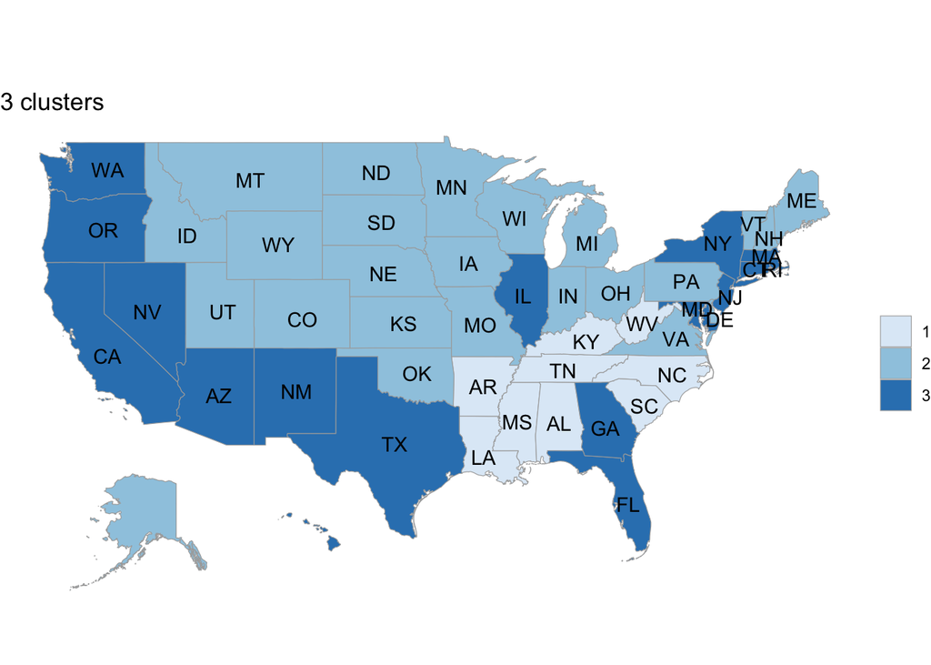

```r
# Map the 3 cluster assignments
maps <- state_sub %>%
    add_rownames("region") %>%
    mutate(region = tolower(region), value = factor(cluster_3)) %>%
    dplyr::select(region, value)
state_choropleth(maps, num_colors = 3, title = "3 clusters")
```

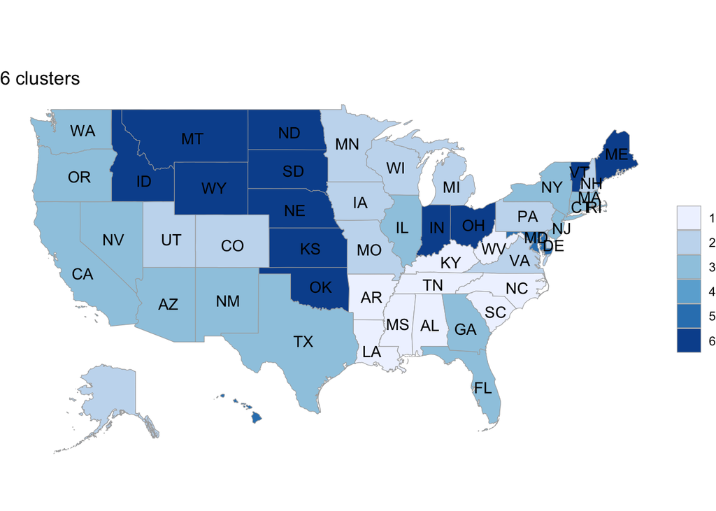

```r
# Map the 6 cluster assignments
maps <- state_sub %>%
    add_rownames("region") %>%
    mutate(region = tolower(region), value = factor(cluster_6)) %>%
    dplyr::select(region, value)
state_choropleth(maps, num_colors = 6, title = "6 clusters")
```

### 4c)

```r
state_sub %>%
    group_by(as.factor(cluster_3)) %>%
    summarize_at(vars(-cluster_3), funs(mean(., na.rm=TRUE))) %>%
    data.frame()
```

```
##   as.factor.cluster_3. median_house_inc share_unemp_seas share_pop_metro
## 1                    1         42543.78       0.05866667       0.6744444
## 2                    2         57400.67       0.04216667       0.6604167
## 3                    3         58660.78       0.05488889       0.9077778
##   share_pop_hs share_non_citizen share_white_poverty gini_index
## 1    0.8251111        0.03000000          0.12555556  0.4647778
## 2    0.8930000        0.03545455          0.08708333  0.4398333
## 3    0.8592778        0.08888889          0.08111111  0.4668333
##   share_non_white share_vote_trump cluster_6
## 1       0.3000000        0.5977778        NA
## 2       0.2120833        0.5241667        NA
## 3       0.4616667        0.3905556        NA
```

```r
state_sub %>%
    group_by(as.factor(cluster_6)) %>%
    summarize_at(vars(-cluster_6), funs(mean(., na.rm=TRUE))) %>%
    data.frame()
```

```
##   as.factor.cluster_6. median_house_inc share_unemp_seas share_pop_metro
## 1                    1         42543.78       0.05866667       0.6744444
## 2                    2         61330.67       0.04491667       0.7691667
## 3                    3         56015.27       0.05573333       0.9073333
## 4                    4         68277.00       0.06700000       1.0000000
## 5                    5         73694.00       0.04250000       0.8650000
## 6                    6         53470.67       0.03941667       0.5516667
##   share_pop_hs share_non_citizen share_white_poverty gini_index
## 1    0.8251111        0.03000000          0.12555556  0.4647778
## 2    0.8930833        0.04000000          0.07500000  0.4405000
## 3    0.8534667        0.08866667          0.08600000  0.4663333
## 4    0.8710000        0.11000000          0.04000000  0.5320000
## 5    0.8970000        0.08000000          0.06500000  0.4380000
## 6    0.8929167        0.03000000          0.09916667  0.4391667
##   share_non_white share_vote_trump cluster_3
## 1       0.3000000        0.5977778        NA
## 2       0.2491667        0.4808333        NA
## 3       0.4246667        0.4226667        NA
## 4       0.6300000        0.0400000        NA
## 5       0.6550000        0.3250000        NA
## 6       0.1750000        0.5675000        NA
```

# Excercises Part two

```r
library(fivethirtyeight)
data("nfl_fav_team")
?nfl_fav_team
```

```r
# Turn state variable into row names
team_sub <- nfl_fav_team %>%
    dplyr::select(-team)
rownames(team_sub) <- nfl_fav_team$team
```

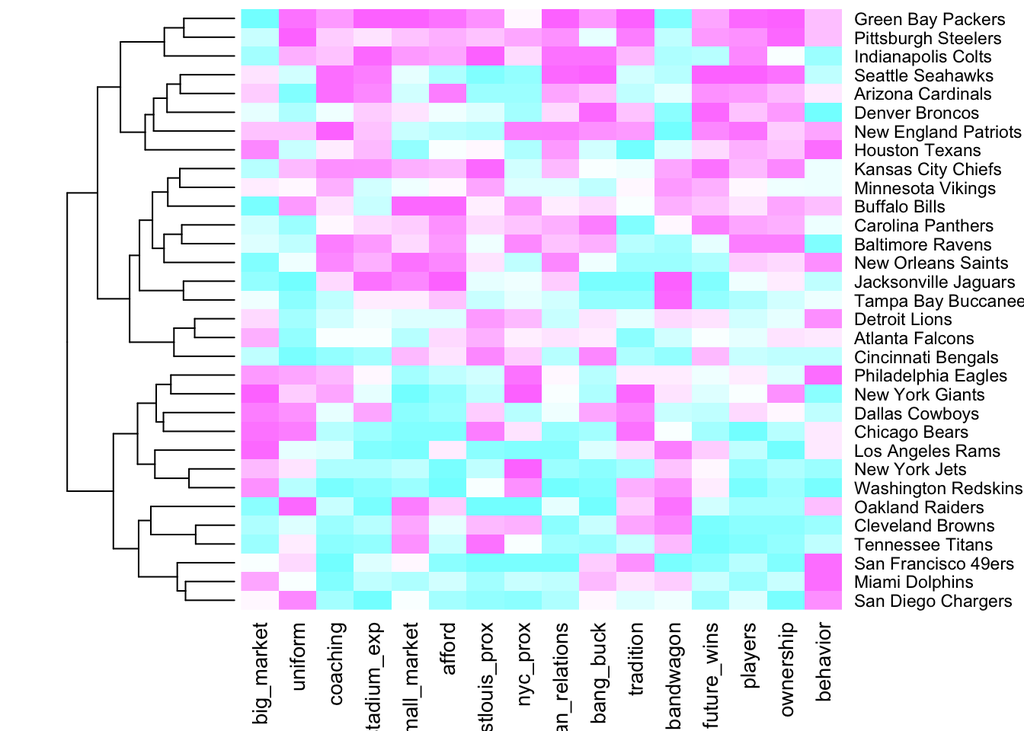

```r
# Heatmap of scaled data
heatmap(data.matrix(scale(team_sub)),
        Colv = NA, scale = "column", col = cm.colors(256))
```

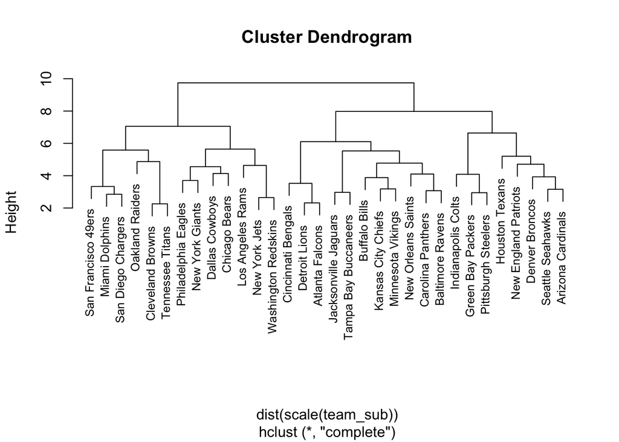

```r
# Dendrogram of scaled data
team_cluster <- hclust(dist(scale(team_sub)))
plot(team_cluster, cex = 0.8)
```

From the above there appear to be four natural clusters for nfl teams. From my knowledge of NFL teams based on both team composition, attributes, and location I cannot make sense of the clustering right off the bat. So I will define the clusters and look at it more closely.

```r
cluster_4 <- as.factor(cutree(team_cluster, 4))
cluster_4
```

```
##    Green Bay Packers  Pittsburgh Steelers   Kansas City Chiefs
##                    1                    1                    2
## New England Patriots        Buffalo Bills    Carolina Panthers
##                    1                    2                    2
##     Seattle Seahawks   Indianapolis Colts    Arizona Cardinals
##                    1                    1                    1
##     Baltimore Ravens       Houston Texans   New Orleans Saints
##                    2                    1                    2
##  Philadelphia Eagles       Denver Broncos        Detroit Lions
##                    3                    1                    2
##    Minnesota Vikings      New York Giants      Atlanta Falcons
##                    2                    3                    2
##       Dallas Cowboys Jacksonville Jaguars       Miami Dolphins
##                    3                    2                    4
##   Cincinnati Bengals      Oakland Raiders Tampa Bay Buccaneers
##                    2                    4                    2
##     Los Angeles Rams        Chicago Bears     Cleveland Browns
##                    3                    3                    4
##   San Diego Chargers  San Francisco 49ers        New York Jets
##                    4                    4                    3
##  Washington Redskins     Tennessee Titans
##                    3                    4
## Levels: 1 2 3 4
```

```r
team_sub <- team_sub %>%
    mutate(cluster_4)

head(team_sub)
```

```
## # A tibble: 6 x 17
##   big_market uniform coaching stadium_exp small_market afford stlouis_prox
##        <int>   <int>    <int>       <int>        <int>  <int>        <int>
## 1          0      94       81         100          100     94           84
## 2         32     100       65          58           68     74           68
## 3         26      71       84          84           74     71           97
## 4         68      68      100          68           32     26           23
## 5          3      81       58          32           97     97           55
## 6         35      16       52          61           65     84           61
## # ... with 10 more variables: nyc_prox <int>, fan_relations <int>,
## #   bang_buck <int>, tradition <int>, bandwagon <int>, future_wins <int>,
## #   players <int>, ownership <int>, behavior <int>, cluster_4 <fct>
```

Now that we can see the clusters, I will look at the means to see if I can determine why the teams are clustered the way they are.

```r
team_sub %>%
    group_by(as.factor(cluster_4)) %>%
    summarize_at(vars(-cluster_4), funs(mean(., na.rm=TRUE))) %>%
    data.frame()
```

```
##   as.factor.cluster_4. big_market  uniform coaching stadium_exp
## 1                    1   46.37500 54.00000 75.50000    79.50000
## 2                    2   35.09091 30.81818 57.36364    57.09091
## 3                    3   88.14286 63.14286 40.14286    32.28571
## 4                    4   37.66667 64.50000 13.83333    18.33333
##   small_market   afford stlouis_prox nyc_prox fan_relations bang_buck
## 1     53.62500 59.62500     48.50000 43.87500      85.50000  75.12500
## 2     64.90909 72.54545     64.45455 56.09091      55.45455  51.18182
## 3     11.85714 17.42857     43.71429 66.85714      25.71429  28.57143
## 4     62.33333 33.83333     33.33333 27.83333      21.00000  39.33333
##   tradition bandwagon future_wins  players ownership behavior
## 1  59.25000  21.87500    76.62500 85.62500  78.00000 51.37500
## 2  25.81818  56.81818    53.36364 53.63636  59.36364 48.45455
## 3  69.57143  62.14286    43.42857 29.85714  34.28571 37.85714
## 4  59.16667  60.83333    16.00000 19.33333  13.83333 64.66667
```